# hw10_group7_final

Author

ST 558 Group 7

## Reading Data

We continue using the Seoul Bike Sharing dataset from HW9. We fit and compare models using tidymodels.

```r
library(readr)
library(dplyr)
library(tidyr)
library(lubridate)
library(ggplot2)
library(tidymodels)
library(baguette)
library(ranger)
library(rpart.plot)
bike_data <- read_csv(
  "https://www4.stat.ncsu.edu/~online/datasets/SeoulBikeData.csv",
  locale = locale(encoding = "latin1")
)
head(bike_data)
```

```
# A tibble: 6 × 14
  Date       `Rented Bike Count`  Hour `Temperature(°C)` `Humidity(%)`
  <chr>                    <dbl> <dbl>             <dbl>         <dbl>
1 01/12/2017                 254     0              -5.2            37
2 01/12/2017                 204     1              -5.5            38
3 01/12/2017                 173     2              -6              39
4 01/12/2017                 107     3              -6.2            40
5 01/12/2017                  78     4              -6              36
6 01/12/2017                 100     5              -6.4            37
# ℹ 9 more variables: `Wind speed (m/s)` <dbl>, `Visibility (10m)` <dbl>,
#   `Dew point temperature(°C)` <dbl>, `Solar Radiation (MJ/m2)` <dbl>,
#   `Rainfall(mm)` <dbl>, `Snowfall (cm)` <dbl>, Seasons <chr>, Holiday <chr>,
#   `Functioning Day` <chr>
```

```r
dim(bike_data)
```

```
[1] 8760   14
```

### EDA

We repeat the data checks and preparation from HW9.

#### Checking Missing Values

```r
colSums(is.na(bike_data))
```

```
                     Date         Rented Bike Count                      Hour
                        0                         0                         0
          Temperature(°C)               Humidity(%)          Wind speed (m/s)
                        0                         0                         0
         Visibility (10m) Dew point temperature(°C)   Solar Radiation (MJ/m2)
                        0                         0                         0
             Rainfall(mm)             Snowfall (cm)                   Seasons
                        0                         0                         0
                  Holiday           Functioning Day
                        0                         0
```

#### Checking Variable Types and Values

```r
str(bike_data)
```

```
spc_tbl_ [8,760 × 14] (S3: spec_tbl_df/tbl_df/tbl/data.frame)
 $ Date                     : chr [1:8760] "01/12/2017" "01/12/2017" "01/12/2017" "01/12/2017" ...
 $ Rented Bike Count        : num [1:8760] 254 204 173 107 78 100 181 460 930 490 ...
 $ Hour                     : num [1:8760] 0 1 2 3 4 5 6 7 8 9 ...
 $ Temperature(°C)          : num [1:8760] -5.2 -5.5 -6 -6.2 -6 -6.4 -6.6 -7.4 -7.6 -6.5 ...
 $ Humidity(%)              : num [1:8760] 37 38 39 40 36 37 35 38 37 27 ...
 $ Wind speed (m/s)         : num [1:8760] 2.2 0.8 1 0.9 2.3 1.5 1.3 0.9 1.1 0.5 ...
 $ Visibility (10m)         : num [1:8760] 2000 2000 2000 2000 2000 ...
 $ Dew point temperature(°C): num [1:8760] -17.6 -17.6 -17.7 -17.6 -18.6 -18.7 -19.5 -19.3 -19.8 -22.4 ...
 $ Solar Radiation (MJ/m2)  : num [1:8760] 0 0 0 0 0 0 0 0 0.01 0.23 ...
 $ Rainfall(mm)             : num [1:8760] 0 0 0 0 0 0 0 0 0 0 ...
 $ Snowfall (cm)            : num [1:8760] 0 0 0 0 0 0 0 0 0 0 ...
 $ Seasons                  : chr [1:8760] "Winter" "Winter" "Winter" "Winter" ...
 $ Holiday                  : chr [1:8760] "No Holiday" "No Holiday" "No Holiday" "No Holiday" ...
 $ Functioning Day          : chr [1:8760] "Yes" "Yes" "Yes" "Yes" ...
 - attr(*, "spec")=
  .. cols(
  ..   Date = col_character(),
  ..   `Rented Bike Count` = col_double(),
  ..   Hour = col_double(),
  ..   `Temperature(°C)` = col_double(),
  ..   `Humidity(%)` = col_double(),
  ..   `Wind speed (m/s)` = col_double(),
  ..   `Visibility (10m)` = col_double(),
  ..   `Dew point temperature(°C)` = col_double(),
  ..   `Solar Radiation (MJ/m2)` = col_double(),
  ..   `Rainfall(mm)` = col_double(),
  ..   `Snowfall (cm)` = col_double(),
  ..   Seasons = col_character(),
  ..   Holiday = col_character(),
  ..   `Functioning Day` = col_character()
  .. )
 - attr(*, "problems")=<externalptr>
```

```r
bike_data |>
  select(where(is.numeric)) |>
  summary()
```

```
 Rented Bike Count      Hour       Temperature(°C)   Humidity(%)
 Min.   :   0.0    Min.   : 0.00   Min.   :-17.80   Min.   : 0.00
 1st Qu.: 191.0    1st Qu.: 5.75   1st Qu.:  3.50   1st Qu.:42.00
 Median : 504.5    Median :11.50   Median : 13.70   Median :57.00
 Mean   : 704.6    Mean   :11.50   Mean   : 12.88   Mean   :58.23
 3rd Qu.:1065.2    3rd Qu.:17.25   3rd Qu.: 22.50   3rd Qu.:74.00
 Max.   :3556.0    Max.   :23.00   Max.   : 39.40   Max.   :98.00
 Wind speed (m/s) Visibility (10m) Dew point temperature(°C)
 Min.   :0.000    Min.   :  27     Min.   :-30.600
 1st Qu.:0.900    1st Qu.: 940     1st Qu.: -4.700
 Median :1.500    Median :1698     Median :  5.100
 Mean   :1.725    Mean   :1437     Mean   :  4.074
 3rd Qu.:2.300    3rd Qu.:2000     3rd Qu.: 14.800
 Max.   :7.400    Max.   :2000     Max.   : 27.200
 Solar Radiation (MJ/m2)  Rainfall(mm)     Snowfall (cm)
 Min.   :0.0000          Min.   : 0.0000   Min.   :0.00000
 1st Qu.:0.0000          1st Qu.: 0.0000   1st Qu.:0.00000
 Median :0.0100          Median : 0.0000   Median :0.00000
 Mean   :0.5691          Mean   : 0.1487   Mean   :0.07507
 3rd Qu.:0.9300          3rd Qu.: 0.0000   3rd Qu.:0.00000
 Max.   :3.5200          Max.   :35.0000   Max.   :8.80000
```

```r
unique(bike_data$Seasons)
```

```
[1] "Winter" "Spring" "Summer" "Autumn"
```

```r
unique(bike_data$Holiday)
```

```
[1] "No Holiday" "Holiday"
```

```r
unique(bike_data$`Functioning Day`)
```

```
[1] "Yes" "No"
```

#### Cleaning the Data

We rename the columns, convert dates and change categorical variables to factors.

```r
bike <- bike_data

names(bike) <- c(
  "date", "rented_count", "hour", "temp",
  "humidity", "wind_speed", "visibility",
  "dew_point_temp", "solar_radiation",
  "rainfall", "snowfall", "seasons",
  "holiday", "functioning_day"
)

bike <- bike |>
  mutate(date = dmy(date)) |>
  mutate(
    across(
      c(seasons, holiday, functioning_day),
      as.factor
    )
  )

head(bike)
```

```
# A tibble: 6 × 14
  date       rented_count  hour  temp humidity wind_speed visibility
  <date>            <dbl> <dbl> <dbl>    <dbl>      <dbl>      <dbl>
1 2017-12-01          254     0  -5.2       37        2.2       2000
2 2017-12-01          204     1  -5.5       38        0.8       2000
3 2017-12-01          173     2  -6         39        1         2000
4 2017-12-01          107     3  -6.2       40        0.9       2000
5 2017-12-01           78     4  -6         36        2.3       2000
6 2017-12-01          100     5  -6.4       37        1.5       2000
# ℹ 7 more variables: dew_point_temp <dbl>, solar_radiation <dbl>,
#   rainfall <dbl>, snowfall <dbl>, seasons <fct>, holiday <fct>,
#   functioning_day <fct>
```

#### Hourly Summary Statistics

```r
bike |>
  summarize(
    mean_bikes = mean(rented_count),
    median_bikes = median(rented_count),
    sd_bikes = sd(rented_count),
    min_bikes = min(rented_count),
    max_bikes = max(rented_count)
  )
```

```
# A tibble: 1 × 5
  mean_bikes median_bikes sd_bikes min_bikes max_bikes
       <dbl>        <dbl>    <dbl>     <dbl>     <dbl>
1       705.         504.     645.         0      3556
```

```r
bike |>
  group_by(seasons) |>
  summarize(
    mean_bikes = mean(rented_count),
    median_bikes = median(rented_count),
    sd_bikes = sd(rented_count),
    min_bikes = min(rented_count),
    max_bikes = max(rented_count),
    .groups = "drop"
  )
```

```
# A tibble: 4 × 6
  seasons mean_bikes median_bikes sd_bikes min_bikes max_bikes
  <fct>        <dbl>        <dbl>    <dbl>     <dbl>     <dbl>
1 Autumn        820.         764.     651.         0      3298
2 Spring        730.         583      622.         0      3251
3 Summer       1034.         906.     690.         9      3556
4 Winter        226.         203      150.         3       937
```

```r
bike |>
  group_by(holiday) |>
  summarize(
    mean_bikes = mean(rented_count),
    median_bikes = median(rented_count),
    sd_bikes = sd(rented_count),
    min_bikes = min(rented_count),
    max_bikes = max(rented_count),
    .groups = "drop"
  )
```

```
# A tibble: 2 × 6
  holiday    mean_bikes median_bikes sd_bikes min_bikes max_bikes
  <fct>           <dbl>        <dbl>    <dbl>     <dbl>     <dbl>
1 Holiday          500.         240      571.         0      2400
2 No Holiday       715.         524.     647.         0      3556
```

```r
bike |>
  group_by(functioning_day) |>
  summarize(
    mean_bikes = mean(rented_count),
    median_bikes = median(rented_count),
    sd_bikes = sd(rented_count),
    min_bikes = min(rented_count),
    max_bikes = max(rented_count),
    .groups = "drop"
  )
```

```
# A tibble: 2 × 6
  functioning_day mean_bikes median_bikes sd_bikes min_bikes max_bikes
  <fct>                <dbl>        <dbl>    <dbl>     <dbl>     <dbl>
1 No                      0             0       0          0         0
2 Yes                   729.          542     642.         2      3556
```

#### Removing Non-Functioning Hours

We remove observations when the rental system was not operating.

```r
bike <- bike |>
  filter(functioning_day == "Yes")

dim(bike)
```

```
[1] 8465   14
```

#### Creating Daily Data

We sum bike rentals, rainfall and snowfall for each day. We average the other weather variables.

```r
daily <- bike |>
  group_by(date, seasons, holiday) |>
  summarise(
    rented_count = sum(rented_count),
    rainfall = sum(rainfall),
    snowfall = sum(snowfall),
    temp = mean(temp),
    humidity = mean(humidity),
    wind_speed = mean(wind_speed),
    visibility = mean(visibility),
    dew_point_temp = mean(dew_point_temp),
    solar_radiation = mean(solar_radiation),
    .groups = "drop"
  )

daily
```

```
# A tibble: 353 × 12
   date       seasons holiday    rented_count rainfall snowfall    temp humidity
   <date>     <fct>   <fct>             <dbl>    <dbl>    <dbl>   <dbl>    <dbl>
 1 2017-12-01 Winter  No Holiday         9539      0        0   -2.45       45.9
 2 2017-12-02 Winter  No Holiday         8523      0        0    1.33       62.0
 3 2017-12-03 Winter  No Holiday         7222      4        0    4.88       81.5
 4 2017-12-04 Winter  No Holiday         8729      0.1      0   -0.304      52.5
 5 2017-12-05 Winter  No Holiday         8307      0        0   -4.46       36.4
 6 2017-12-06 Winter  No Holiday         6669      1.3      8.6  0.0458     70.8
 7 2017-12-07 Winter  No Holiday         8549      0       10.4  1.09       67.5
 8 2017-12-08 Winter  No Holiday         8032      0        0   -3.82       41.8
 9 2017-12-09 Winter  No Holiday         7233      0        0   -0.846      46
10 2017-12-10 Winter  No Holiday         3453      4.1     32.5  1.19       69.7
# ℹ 343 more rows
# ℹ 4 more variables: wind_speed <dbl>, visibility <dbl>, dew_point_temp <dbl>,
#   solar_radiation <dbl>
```

```r
dim(daily)
```

```
[1] 353  12
```

#### Daily Summary Statistics

```r
summary(daily)
```

```
      date              seasons         holiday     rented_count
 Min.   :2017-12-01   Autumn:81   Holiday   : 17   Min.   :  977
 1st Qu.:2018-02-27   Spring:90   No Holiday:336   1st Qu.: 6967
 Median :2018-05-28   Summer:92                    Median :18563
 Mean   :2018-05-28   Winter:90                    Mean   :17485
 3rd Qu.:2018-08-24                                3rd Qu.:26285
 Max.   :2018-11-30                                Max.   :36149
    rainfall         snowfall           temp            humidity
 Min.   : 0.000   Min.   : 0.000   Min.   :-14.738   Min.   :22.25
 1st Qu.: 0.000   1st Qu.: 0.000   1st Qu.:  3.304   1st Qu.:47.58
 Median : 0.000   Median : 0.000   Median : 13.738   Median :57.17
 Mean   : 3.576   Mean   : 1.863   Mean   : 12.776   Mean   :58.17
 3rd Qu.: 0.500   3rd Qu.: 0.000   3rd Qu.: 22.592   3rd Qu.:67.71
 Max.   :95.500   Max.   :78.700   Max.   : 33.742   Max.   :95.88
   wind_speed       visibility     dew_point_temp    solar_radiation
 Min.   :0.6625   Min.   : 214.3   Min.   :-27.750   Min.   :0.02917
 1st Qu.:1.3042   1st Qu.:1087.0   1st Qu.: -5.188   1st Qu.:0.28333
 Median :1.6583   Median :1557.8   Median :  4.612   Median :0.56500
 Mean   :1.7261   Mean   :1434.0   Mean   :  3.954   Mean   :0.56773
 3rd Qu.:1.9542   3rd Qu.:1874.3   3rd Qu.: 14.921   3rd Qu.:0.82000
 Max.   :4.0000   Max.   :2000.0   Max.   : 25.038   Max.   :1.21667
```

```r
daily |>
  group_by(seasons) |>
  summarize(
    mean_bikes = mean(rented_count),
    median_bikes = median(rented_count),
    sd_bikes = sd(rented_count),
    .groups = "drop"
  )
```

```
# A tibble: 4 × 4
  seasons mean_bikes median_bikes sd_bikes
  <fct>        <dbl>        <dbl>    <dbl>
1 Autumn      22099.       23350     6711.
2 Spring      17910.       17590     8357.
3 Summer      24818.       25572.    7297.
4 Winter       5413.        5498     1808.
```

```r
daily |>
  group_by(holiday) |>
  summarize(
    mean_bikes = mean(rented_count),
    median_bikes = median(rented_count),
    sd_bikes = sd(rented_count),
    .groups = "drop"
  )
```

```
# A tibble: 2 × 4
  holiday    mean_bikes median_bikes sd_bikes
  <fct>           <dbl>        <dbl>    <dbl>
1 Holiday        12700.        7184    10504.
2 No Holiday     17727.       19104.    9862.
```

#### Daily Rentals Over Time

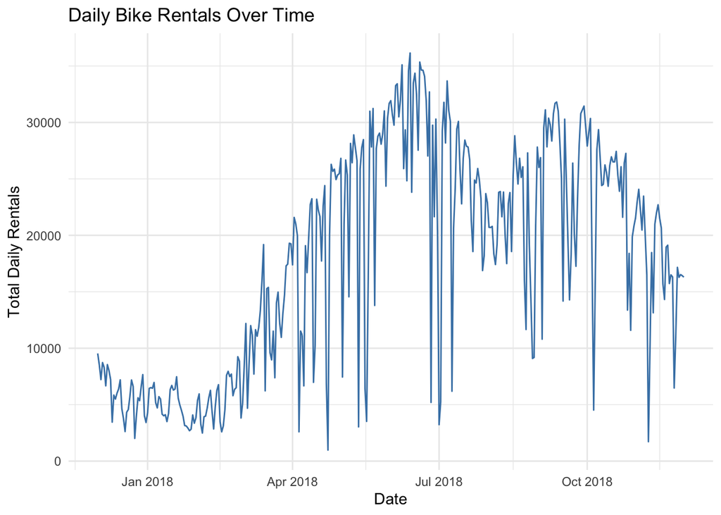

```r
ggplot(daily, aes(x = date, y = rented_count)) +
  geom_line(color = "steelblue") +
  labs(
    title = "Daily Bike Rentals Over Time",
    x = "Date",
    y = "Total Daily Rentals"
  ) +
  theme_minimal()
```

#### Daily Rentals by Season

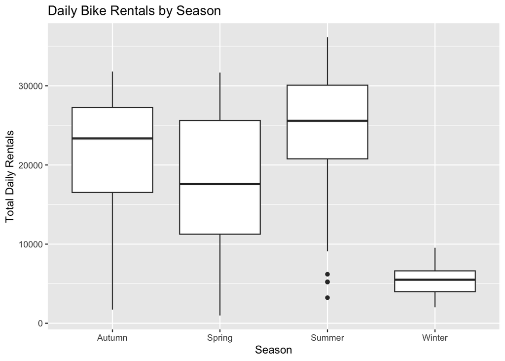

```r
ggplot(daily, aes(x = seasons, y = rented_count)) +
  geom_boxplot() +
  labs(
    title = "Daily Bike Rentals by Season",
    x = "Season",
    y = "Total Daily Rentals"
  )
```

#### Daily Rentals by Temperature

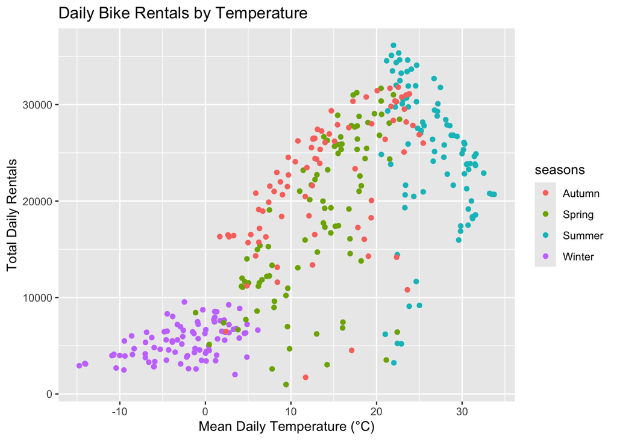

```r
ggplot(
  daily,
  aes(x = temp, y = rented_count, color = seasons)
) +
  geom_point() +
  labs(
    title = "Daily Bike Rentals by Temperature",
    x = "Mean Daily Temperature (°C)",
    y = "Total Daily Rentals"
  )
```

#### Rentals by Holiday and Season

We calculate the mean daily rentals for each combination before drawing the heatmap.

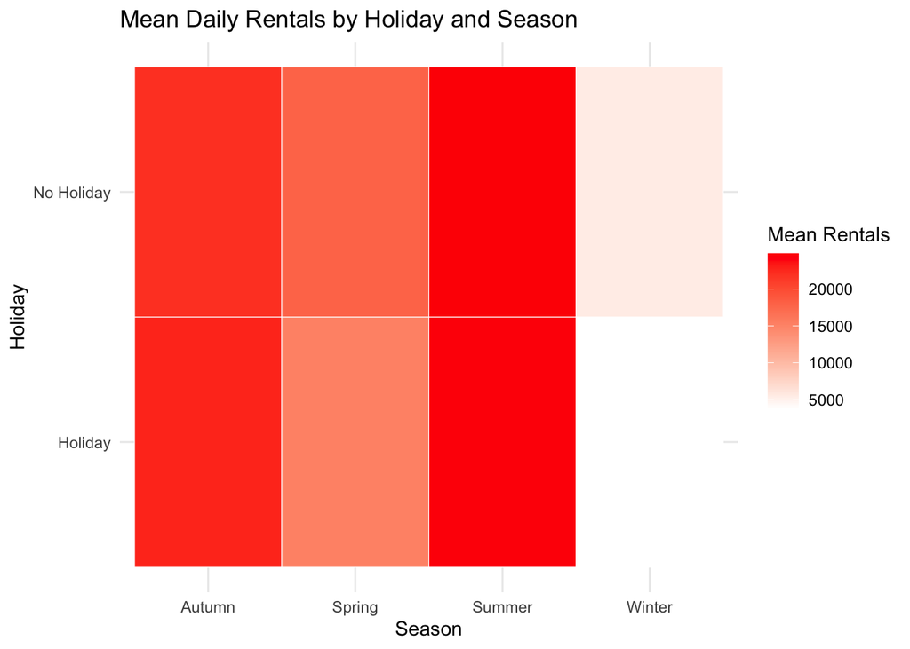

```r
holiday_season_summary <- daily |>
  group_by(seasons, holiday) |>
  summarize(
    mean_rentals = mean(rented_count),
    .groups = "drop"
  )

ggplot(
  holiday_season_summary,
  aes(x = seasons, y = holiday, fill = mean_rentals)
) +
  geom_tile(color = "white") +
  scale_fill_gradient(low = "white", high = "red") +
  labs(
    title = "Mean Daily Rentals by Holiday and Season",
    x = "Season",
    y = "Holiday",
    fill = "Mean Rentals"
  ) +
  theme_minimal()
```

#### Correlations

```r
round(
  cor(daily |> select(where(is.numeric))),
  2
)
```

```
                rented_count rainfall snowfall  temp humidity wind_speed
rented_count            1.00    -0.24    -0.27  0.75     0.04      -0.19
rainfall               -0.24     1.00    -0.02  0.14     0.53      -0.10
snowfall               -0.27    -0.02     1.00 -0.27     0.07       0.02
temp                    0.75     0.14    -0.27  1.00     0.40      -0.26
humidity                0.04     0.53     0.07  0.40     1.00      -0.23
wind_speed             -0.19    -0.10     0.02 -0.26    -0.23       1.00
visibility              0.17    -0.22    -0.10  0.00    -0.56       0.21
dew_point_temp          0.65     0.26    -0.21  0.96     0.63      -0.29
solar_radiation         0.74    -0.32    -0.23  0.55    -0.27       0.10
                visibility dew_point_temp solar_radiation
rented_count          0.17           0.65            0.74
rainfall             -0.22           0.26           -0.32
snowfall             -0.10          -0.21           -0.23
temp                  0.00           0.96            0.55
humidity             -0.56           0.63           -0.27
wind_speed            0.21          -0.29            0.10
visibility            1.00          -0.15            0.27
dew_point_temp       -0.15           1.00            0.38
solar_radiation       0.27           0.38            1.00
```

Temperature has a strong positive correlation with daily bike rentals. Solar radiation also has a strong positive relationship with rentals.

## Split the Data

We use a 75/25 split stratified by seasons. We then create 10 cross-validation folds from the training set.

```r
set.seed(558)

bike_split <- initial_split(
  daily,
  prop = 0.75,
  strata = seasons
)

bike_train <- training(bike_split)
bike_test <- testing(bike_split)

bike_folds <- vfold_cv(bike_train, v = 10)

bike_split
```

```
<Training/Testing/Total>
<263/90/353>
```

```r
bike_folds
```

```
#  10-fold cross-validation
# A tibble: 10 × 2
   splits           id
   <list>           <chr>
 1 <split [236/27]> Fold01
 2 <split [236/27]> Fold02
 3 <split [236/27]> Fold03
 4 <split [237/26]> Fold04
 5 <split [237/26]> Fold05
 6 <split [237/26]> Fold06
 7 <split [237/26]> Fold07
 8 <split [237/26]> Fold08
 9 <split [237/26]> Fold09
10 <split [237/26]> Fold10
```

## Fitting MLR Models

### Recipes

#### Recipe 1

We create a weekday/weekend factor from the date. We give the original date an ID role, standardize numeric predictors and create dummy variables.

```r
MLR_recipe1 <- recipe(
  rented_count ~ .,
  data = bike_train
) |>
  update_role(date, new_role = "id") |>
  step_date(date, features = "dow") |>
  step_mutate(
    day_type = factor(
      if_else(
        date_dow %in% c("Sat", "Sun"),
        "weekend",
        "weekday"
      )
    )
  ) |>
  step_rm(date_dow) |>
  step_normalize(all_numeric_predictors()) |>
  step_dummy(seasons, holiday, day_type)

MLR_recipe1
```

```
── Recipe ──────────────────────────────────────────────────────────────────────
```

```
── Inputs
```

```
Number of variables by role
```

```
outcome:    1
predictor: 10
id:         1
```

```
── Operations
```

```
• Date features from: date
```

```
• Variable mutation for: factor(if_else(date_dow %in% c("Sat", "Sun"),
  "weekend", "weekday"))
```

```
• Variables removed: date_dow
```

```
• Centering and scaling for: all_numeric_predictors()
```

```
• Dummy variables from: seasons, holiday, day_type
```

#### Recipe 2

We add interactions between seasons and holiday, seasons and temperature plus temperature and rainfall.

```r
MLR_recipe2 <- recipe(
  rented_count ~ .,
  data = bike_train
) |>
  update_role(date, new_role = "id") |>
  step_date(date, features = "dow") |>
  step_mutate(
    day_type = factor(
      if_else(
        date_dow %in% c("Sat", "Sun"),
        "weekend",
        "weekday"
      )
    )
  ) |>
  step_rm(date_dow) |>
  step_normalize(all_numeric_predictors()) |>
  step_dummy(seasons, holiday, day_type) |>
  step_interact(
    ~ starts_with("seasons"):starts_with("holiday") +
      starts_with("seasons"):temp +
      temp:rainfall
  )

MLR_recipe2
```

```
── Recipe ──────────────────────────────────────────────────────────────────────
```

```
── Inputs
```

```
Number of variables by role
```

```
outcome:    1
predictor: 10
id:         1
```

```
── Operations
```

```
• Date features from: date
```

```
• Variable mutation for: factor(if_else(date_dow %in% c("Sat", "Sun"),
  "weekend", "weekday"))
```

```
• Variables removed: date_dow
```

```
• Centering and scaling for: all_numeric_predictors()
```

```
• Dummy variables from: seasons, holiday, day_type
```

```
• Interactions with: ...
```

#### Recipe 3

We keep the interactions and add squared terms for standardized temperature and humidity.

```r
MLR_recipe3 <- recipe(
  rented_count ~ .,
  data = bike_train
) |>
  update_role(date, new_role = "id") |>
  step_date(date, features = "dow") |>
  step_mutate(
    day_type = factor(
      if_else(
        date_dow %in% c("Sat", "Sun"),
        "weekend",
        "weekday"
      )
    )
  ) |>
  step_rm(date_dow) |>
  step_normalize(all_numeric_predictors()) |>
  step_dummy(seasons, holiday, day_type) |>
  step_interact(
    ~ starts_with("seasons"):starts_with("holiday") +
      starts_with("seasons"):temp +
      temp:rainfall
  ) |>
  step_mutate(
    tetmp_sq = temp^2,
    humidity_sq = humidity^2
  )

MLR_recipe3
```

```
── Recipe ──────────────────────────────────────────────────────────────────────
```

```
── Inputs
```

```
Number of variables by role
```

```
outcome:    1
predictor: 10
id:         1
```

```
── Operations
```

```
• Date features from: date
```

```
• Variable mutation for: factor(if_else(date_dow %in% c("Sat", "Sun"),
  "weekend", "weekday"))
```

```
• Variables removed: date_dow
```

```
• Centering and scaling for: all_numeric_predictors()
```

```
• Dummy variables from: seasons, holiday, day_type
```

```
• Interactions with: ...
```

```
• Variable mutation for: temp^2 humidity^2
```

### Fit via 10-Fold CV

We use the lm engine for all three recipes.

```r
MLR_spec <- linear_reg() |>
  set_engine("lm")

MLR_workflow1 <- workflow() |>
  add_recipe(MLR_recipe1) |>
  add_model(MLR_spec)

MLR_workflow2 <- workflow() |>
  add_recipe(MLR_recipe2) |>
  add_model(MLR_spec)

MLR_workflow3 <- workflow() |>
  add_recipe(MLR_recipe3) |>
  add_model(MLR_spec)

MLR_workflows <- list(
  recipe1 = MLR_workflow1,
  recipe2 = MLR_workflow2,
  recipe3 = MLR_workflow3
)

MLR_results <- bind_rows(
  fit_resamples(MLR_workflow1, bike_folds) |>
    collect_metrics() |>
    mutate(model = "recipe1"),

  fit_resamples(MLR_workflow2, bike_folds) |>
    collect_metrics() |>
    mutate(model = "recipe2"),

  fit_resamples(MLR_workflow3, bike_folds) |>
    collect_metrics() |>
    mutate(model = "recipe3")
)
```

```
→ A | warning: prediction from rank-deficient fit; consider predict(., rankdeficient="NA")
```

```
There were issues with some computations   A: x1
```

```
There were issues with some computations   A: x2
```

```
→ A | warning: prediction from rank-deficient fit; consider predict(., rankdeficient="NA")
```

```
There were issues with some computations   A: x2
There were issues with some computations   A: x2
```

```r
MLR_results |>
  filter(.metric == "rmse") |>
  select(model, mean, std_err) |>
  knitr::kable(
    digits = 2,
    caption = "MLR Cross-Validation RMSE"
  )
```

MLR Cross-Validation RMSE

| model | mean | std_err |
| --- | --- | --- |
| recipe1 | 4095.25 | 203.69 |
| recipe2 | 3079.68 | 291.21 |
| recipe3 | 3038.55 | 291.82 |

We choose the recipe with the lowest mean cross-validation RMSE.

```r
MLR_best_workflow <- MLR_results |>
  filter(.metric == "rmse") |>
  arrange(mean) |>
  slice(1)

MLR_best_workflow
```

```
# A tibble: 1 × 7
  .metric .estimator  mean     n std_err .config         model
  <chr>   <chr>      <dbl> <int>   <dbl> <chr>           <chr>
1 rmse    standard   3039.    10    292. pre0_mod0_post0 recipe3
```

```r
last_mlr <- last_fit(
  MLR_workflows[[MLR_best_workflow$model]],
  bike_split,
  metrics = metric_set(
    yardstick::rmse,
    yardstick::mae
  )
)

collect_metrics(last_mlr)
```

```
# A tibble: 2 × 4
  .metric .estimator .estimate .config
  <chr>   <chr>          <dbl> <chr>
1 rmse    standard       3059. pre0_mod0_post0
2 mae     standard       2132. pre0_mod0_post0
```

The selected recipe is **recipe3**. Its mean cross-validation RMSE is **3038.55**.

## Fitting Other Models

We use the first MLR recipe for all three tree-based models. We tune each model using the training folds.

### Regression Tree

We tune cost complexity and tree depth.

```r
tree_spec <- decision_tree(
  cost_complexity = tune(),
  tree_depth = tune()
) |>
  set_engine("rpart") |>
  set_mode("regression")

tree_workflow <- workflow() |>
  add_recipe(MLR_recipe1) |>
  add_model(tree_spec)

tree_grid <- tree_workflow |>
  tune_grid(
    resamples = bike_folds,
    grid = grid_regular(
      cost_complexity(),
      tree_depth(),
      levels = 5
    )
  )

tree_best_params <- tree_grid |>
  select_best(metric = "rmse")

tree_best_params
```

```
# A tibble: 1 × 3
  cost_complexity tree_depth .config
            <dbl>      <int> <chr>
1    0.0000000001         11 pre0_mod04_post0
```

```r
tree_final_workflow <- tree_workflow |>
  finalize_workflow(tree_best_params)

tree_final_fit <- tree_final_workflow |>
  fit(bike_train)
```

### Bagged Tree

We combine 25 trees and tune cost complexity and tree depth.

```r
bag_spec <- bag_tree(
  cost_complexity = tune(),
  tree_depth = tune()
) |>
  set_engine("rpart", times = 25) |>
  set_mode("regression")

bag_workflow <- workflow() |>
  add_recipe(MLR_recipe1) |>
  add_model(bag_spec)

bag_grid <- bag_workflow |>
  tune_grid(
    resamples = bike_folds,
    grid = grid_regular(
      cost_complexity(),
      tree_depth(),
      levels = 3
    )
  )
bag_best_params <- bag_grid |>
  select_best(metric = "rmse")

bag_best_params
```

```
# A tibble: 1 × 3
  cost_complexity tree_depth .config
            <dbl>      <int> <chr>
1    0.0000000001         15 pre0_mod3_post0
```

```r
bag_final_workflow <- bag_workflow |>
  finalize_workflow(bag_best_params)

bag_final_fit <- bag_final_workflow |>
  fit(bike_train)
```

### Random Forest

We use 500 trees and tune mtry and min_n. We enable impurity importance for the variable importance plot.

```r
rf_spec <- rand_forest(
  mtry = tune(),
  min_n = tune(),
  trees = 500
) |>
  set_engine("ranger", importance = "impurity") |>
  set_mode("regression")

rf_workflow <- workflow() |>
  add_recipe(MLR_recipe1) |>
  add_model(rf_spec)

rf_grid <- rf_workflow |>
  tune_grid(
    resamples = bike_folds,
    grid = grid_regular(
      mtry(range = c(2, 10)),
      min_n(range = c(2, 10)),
      levels = 3
    )
  )

rf_best_params <- rf_grid |>
  select_best(metric = "rmse")

rf_best_params
```

```
# A tibble: 1 × 3
   mtry min_n .config
  <int> <int> <chr>
1    10     6 pre0_mod8_post0
```

```r
rf_final_workflow <- rf_workflow |>
  finalize_workflow(rf_best_params)

rf_final_fit <- rf_final_workflow |>
  fit(bike_train)
```

## Compare on the Test Set

We fit each selected workflow on the full training set and evaluate it on the same test set. Lower RMSE and MAE mean smaller prediction errors.

```r
last_tree <- last_fit(
  tree_final_workflow,
  bike_split,
  metrics = metric_set(
    yardstick::rmse,
    yardstick::mae
  )
)

last_bag <- last_fit(
  bag_final_workflow,
  bike_split,
  metrics = metric_set(
    yardstick::rmse,
    yardstick::mae
  )
)

last_rf <- last_fit(
  rf_final_workflow,
  bike_split,
  metrics = metric_set(
    yardstick::rmse,
    yardstick::mae
  )
)

test_results <- bind_rows(
  collect_metrics(last_mlr) |>
    mutate(model = "MLR"),

  collect_metrics(last_tree) |>
    mutate(model = "Regression Tree"),

  collect_metrics(last_bag) |>
    mutate(model = "Bagged Tree"),

  collect_metrics(last_rf) |>
    mutate(model = "Random Forest")
)

rmse_table <- test_results |>
  filter(.metric == "rmse") |>
  select(model, rmse = .estimate) |>
  arrange(rmse)

rmse_table |>
  knitr::kable(
    digits = 2,
    caption = "Test RMSE"
  )
```

Test RMSE

| model | rmse |
| --- | --- |
| Bagged Tree | 2304.19 |
| Random Forest | 2320.25 |
| MLR | 3059.35 |
| Regression Tree | 3491.07 |

```r
mae_table <- test_results |>
  filter(.metric == "mae") |>
  select(model, mae = .estimate) |>
  arrange(mae)

mae_table |>
  knitr::kable(
    digits = 2,
    caption = "Test MAE"
  )
```

Test MAE

| model | mae |
| --- | --- |
| Bagged Tree | 1801.83 |
| Random Forest | 1863.24 |
| MLR | 2132.17 |
| Regression Tree | 2496.07 |

## Final Model Summaries

The following summaries use the models fitted to the training data.

### MLR Coefficient Table

We display all coefficients from the selected MLR model.

```r
last_mlr |>
  extract_fit_parsnip() |>
  tidy() |>
  knitr::kable(
    digits = 4,
    caption = "Final MLR Coefficients"
  )
```

Final MLR Coefficients

| term | estimate | std.error | statistic | p.value |
| --- | --- | --- | --- | --- |
| (Intercept) | 14640.3360 | 2099.4514 | 6.9734 | 0.0000 |
| rainfall | -1899.0541 | 368.7884 | -5.1494 | 0.0000 |
| snowfall | -220.4838 | 203.1628 | -1.0853 | 0.2789 |
| temp | -106.5758 | 4246.0205 | -0.0251 | 0.9800 |
| humidity | -2381.2140 | 1586.2055 | -1.5012 | 0.1346 |
| wind_speed | -504.7985 | 216.9980 | -2.3263 | 0.0208 |
| visibility | 119.3305 | 277.8678 | 0.4295 | 0.6680 |
| dew_point_temp | 6375.9707 | 4966.3768 | 1.2838 | 0.2004 |
| solar_radiation | 3250.6980 | 350.4241 | 9.2765 | 0.0000 |
| seasons_Spring | 1016.3687 | 2749.3381 | 0.3697 | 0.7119 |
| seasons_Summer | 19379.7249 | 4272.6326 | 4.5358 | 0.0000 |
| seasons_Winter | -5423.7552 | 3210.7372 | -1.6893 | 0.0925 |
| holiday_No.Holiday | 8719.4661 | 2115.4299 | 4.1218 | 0.0001 |
| day_type_weekend | -2424.7734 | 405.4867 | -5.9799 | 0.0000 |
| seasons_Spring_x_holiday_No.Holiday | -6272.6575 | 2789.9582 | -2.2483 | 0.0255 |
| seasons_Summer_x_holiday_No.Holiday | -4409.2958 | 3643.8714 | -1.2101 | 0.2274 |
| seasons_Winter_x_holiday_No.Holiday | -5280.6372 | 2452.8498 | -2.1529 | 0.0323 |
| seasons_Spring_x_temp | 4671.4130 | 1127.4338 | 4.1434 | 0.0000 |
| seasons_Summer_x_temp | -15852.1442 | 2462.9891 | -6.4361 | 0.0000 |
| seasons_Winter_x_temp | -3825.7750 | 2721.7500 | -1.4056 | 0.1611 |
| temp_x_rainfall | -930.2078 | 428.8702 | -2.1690 | 0.0311 |
| tetmp_sq | -700.6973 | 855.5045 | -0.8190 | 0.4136 |
| humidity_sq | -561.8606 | 229.9047 | -2.4439 | 0.0153 |

### Regression Tree Model

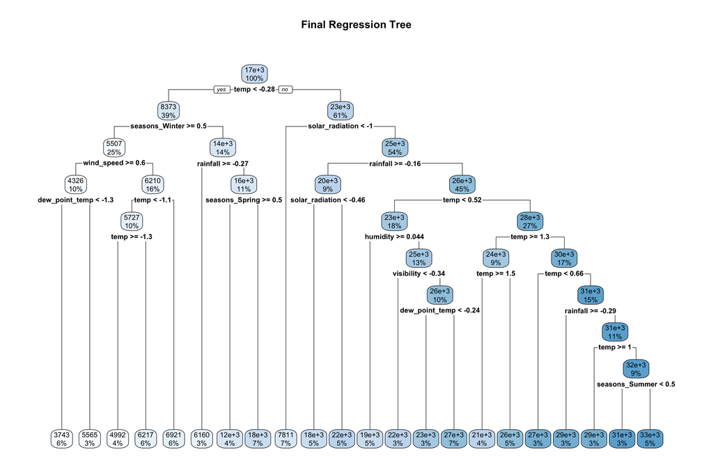

```r
tree_final_fit |>
  extract_fit_engine() |>
  rpart.plot(
    roundint = FALSE,
    main = "Final Regression Tree"
  )
```

### Bagged Tree Variable Importance

We plot the importance scores from the fitted bagged trees.

```r
bag_importance <- bag_final_fit |>
  extract_fit_engine() |>
  baguette::var_imp()

bag_importance |>
  arrange(desc(value)) |>
  knitr::kable(
    digits = 2,
    caption = "Bagged Tree Variable Importance"
  )
```

Bagged Tree Variable Importance

| term | value | std.error | used |
| --- | --- | --- | --- |
| temp | 17541240966 | 334448730 | 25 |
| dew_point_temp | 14443056063 | 392449634 | 25 |
| solar_radiation | 12533857199 | 300025379 | 25 |
| seasons_Winter | 10861815661 | 291993329 | 25 |
| humidity | 8487767931 | 412780218 | 25 |
| rainfall | 3769868344 | 168502581 | 25 |
| wind_speed | 2530474263 | 271937170 | 25 |
| visibility | 2017515506 | 173020360 | 25 |
| snowfall | 1732680378 | 281441935 | 25 |
| seasons_Spring | 1154537973 | 83506407 | 25 |
| seasons_Summer | 736509920 | 151312223 | 25 |
| day_type_weekend | 221339172 | 19427649 | 25 |
| holiday_No.Holiday | 186376473 | 31432935 | 25 |

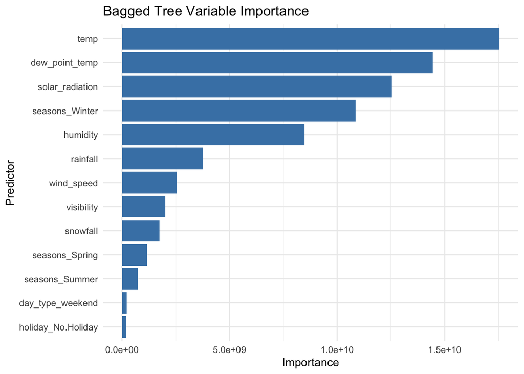

```r
ggplot(
  bag_importance,
  aes(x = reorder(term, value), y = value)
) +
  geom_col(fill = "steelblue") +
  coord_flip() +
  labs(
    title = "Bagged Tree Variable Importance",
    x = "Predictor",
    y = "Importance"
  ) +
  theme_minimal()
```

### Random Forest Variable Importance

We extract the importance scores from the ranger model and plot them.

```r
rf_engine <- rf_final_fit |>
  extract_fit_engine()

rf_importance <- tibble(
  term = names(rf_engine$variable.importance),
  value = as.numeric(rf_engine$variable.importance)
)

rf_importance |>
  arrange(desc(value)) |>
  knitr::kable(
    digits = 2,
    caption = "Random Forest Variable Importance"
  )
```

Random Forest Variable Importance

| term | value |
| --- | --- |
| temp | 12755586344 |
| solar_radiation | 5634162842 |
| seasons_Winter | 2788854103 |
| rainfall | 1303405341 |
| dew_point_temp | 1146976370 |
| humidity | 511318703 |
| visibility | 467157094 |
| wind_speed | 321449147 |
| seasons_Spring | 239980757 |
| day_type_weekend | 127863622 |
| holiday_No.Holiday | 81772927 |
| seasons_Summer | 42443558 |
| snowfall | 15599819 |

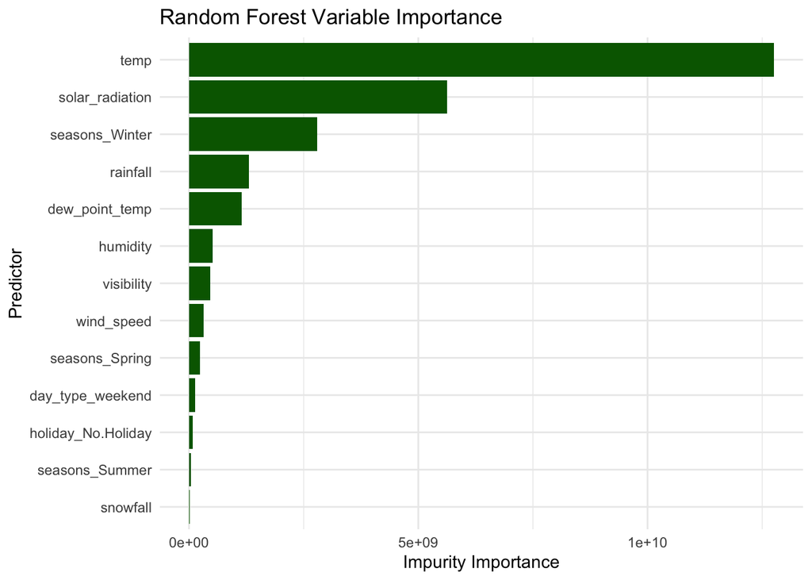

```r
ggplot(
  rf_importance,
  aes(x = reorder(term, value), y = value)
) +
  geom_col(fill = "darkgreen") +
  coord_flip() +
  labs(
    title = "Random Forest Variable Importance",
    x = "Predictor",
    y = "Impurity Importance"
  ) +
  theme_minimal()
```

## Overall Best Model - Refit on Entire Data Set

We select the model with the lowest test RMSE and refit it using all daily observations.

```r
rmse_table
```

```
# A tibble: 4 × 2
  model            rmse
  <chr>           <dbl>
1 Bagged Tree     2304.
2 Random Forest   2320.
3 MLR             3059.
4 Regression Tree 3491.
```

```r
mae_table
```

```
# A tibble: 4 × 2
  model             mae
  <chr>           <dbl>
1 Bagged Tree     1802.
2 Random Forest   1863.
3 MLR             2132.
4 Regression Tree 2496.
```

```r
best_overall <- rmse_table$model[1]
best_overall
```

```
[1] "Bagged Tree"
```

```r
if (best_overall == "MLR") {
  overall_best_workflow <-
    MLR_workflows[[MLR_best_workflow$model]]
} else if (best_overall == "Regression Tree") {
  overall_best_workflow <- tree_final_workflow
} else if (best_overall == "Bagged Tree") {
  overall_best_workflow <- bag_final_workflow
} else {
  overall_best_workflow <- rf_final_workflow
}

overall_best_fit <- overall_best_workflow |>
  fit(daily)

overall_best_fit
```

```
══ Workflow [trained] ══════════════════════════════════════════════════════════
Preprocessor: Recipe
Model: bag_tree()

── Preprocessor ────────────────────────────────────────────────────────────────
5 Recipe Steps

• step_date()
• step_mutate()
• step_rm()
• step_normalize()
• step_dummy()

── Model ───────────────────────────────────────────────────────────────────────
Bagged CART (regression with 25 members)

Variable importance scores include:

# A tibble: 13 × 4
   term                      value  std.error  used
   <chr>                     <dbl>      <dbl> <int>
 1 temp               25104103331. 566935756.    25
 2 dew_point_temp     20838173041. 546922948.    25
 3 solar_radiation    17771635232. 447599598.    25
 4 seasons_Winter     15279445581. 421031822.    25
 5 humidity           10695884604. 491437677.    25
 6 rainfall            4748828085. 227103380.    25
 7 snowfall            3108663029. 492120652.    25
 8 seasons_Summer      2826732155. 625193973.    25
 9 wind_speed          2119295108. 293692944.    25
10 visibility          1862179290. 101853739.    25
11 seasons_Spring      1682040317.  93820278.    25
12 day_type_weekend     315132733.  24739236.    25
13 holiday_No.Holiday   104592625.  17140866.    25
```

## Conclusion

The best MLR recipe based on cross-validation was **recipe3**.

The **Bagged Tree** model had the lowest test RMSE of **2304.19**. Its test MAE was **1801.83**.

We refitted this model using all **353** daily observations.